# Praca domowa ze wstępu do uczenia maszynowego nr 3

Marceli Korbin

6 kwietnia 2020

## Wstęp

Tworzymy model klasyfikacyjny z trzech kandydatów: drzewo klasyfikacyjne *rpart*, kNN, lasy losowe. Modele będziemy sprawdzać na zbiorze danych o pogodzie w Australii.

```r
australia <- read.csv("~/2020L-WUM/Prace_domowe/Praca_domowa3/australia.csv")
library(dplyr)
library(rpart)  # drzewo klasyfikacyjne
library(rattle) # wizualizacja powyższego
library(class)  # kNN
library(ranger) # lasy losowe
australia$RainTomorrow <- factor(australia$RainTomorrow, levels=unique(australia$RainTomorrow), ordered=F)
# wcześniej to był "integer"
```

Każdy model potrzebuje treningowego zbioru danych. Nasz stworzymy z 70% oryginalnego:

```r
baseCol <- 1:(ncol(australia)-1)
classCol <- ncol(australia)
trainID <- sample(1:nrow(australia), nrow(australia)*0.7)
trainDF <- australia[trainID,]
testDF <- australia[-trainID,]
```

Do sprawdzania skuteczności stworzymy kilka funkcji określających *accuracy*, *precision*, *recall*, *specificity* i wynik *F1*.

```r
posneg <- function(predDF){
  tab <- ifelse(predDF$pred=="0" & predDF$actual=="0", "TN",
                 ifelse(predDF$pred=="0" & predDF$actual=="1", "FN",
                        ifelse(predDF$pred=="1" & predDF$actual=="0", "FP", "TP")))
  return(table(tab))
}
accuracy <- function(tab) return((tab['TP']+tab['TN'])/sum(tab))
precision <- function(tab) return((tab['TP'])/(tab['TP']+tab['FP']))
recall <- function(tab) return((tab['TP'])/(tab['TP']+tab['FN']))
specificity <- function(tab) return((tab['TN'])/(tab['TN']+tab['FP']))
# specificity to taki recall, ale dla obserwacji negatywnych
f1 <- function(tab) return(2/(1/precision(tab)+1/recall(tab)))
# średnia harmoniczna z precision i recall
measures <- function(meas) return(c(accuracy=accuracy(meas)[['TP']],
                                    precision=precision(meas)[['TP']],
                                    recall=recall(meas)[['TP']],
                                    specificity=specificity(meas)[['TN']],
                                    F1=f1(meas)[['TP']]))
```

## Modele

### Drzewo klasyfikacyjne

Klasyczne drzewo klasyfikacyjne z pakietu *rpart*.

Zmusimy liście do zebrania co najmniej 15 obserwacji, żeby mogły się rozdzielić. Ustawimy również parametr złożoności *cp* na 0.01 - chodzi z nim o to, że nie dokonuje się podziałów, które obniżają ogólny brak dopasowania o wartość *cp*.

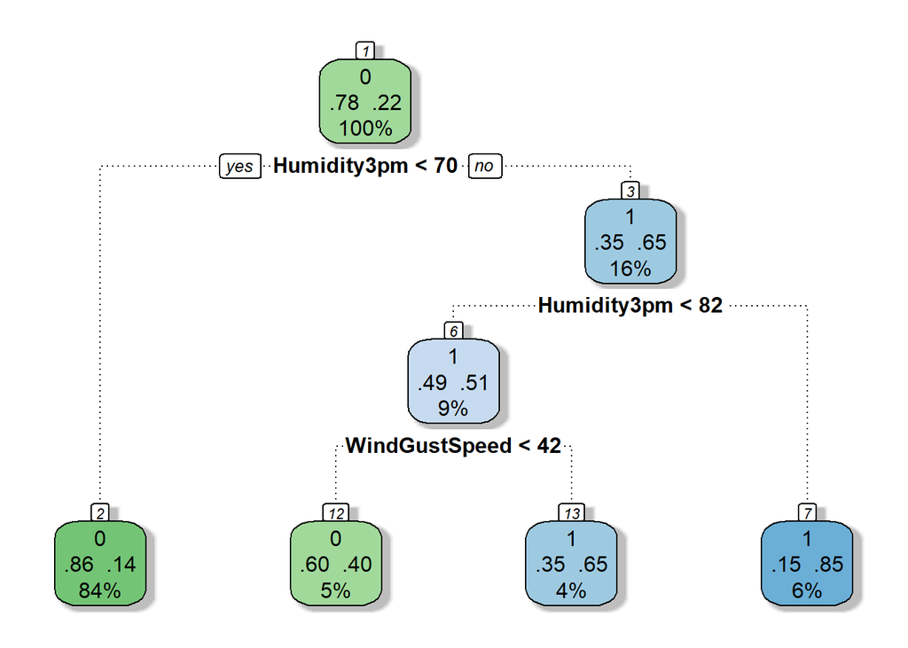

```r
klasyfikator1 <- rpart(RainTomorrow~., data=trainDF, minsplit=15, cp=0.01)
fancyRpartPlot(klasyfikator1, caption=NULL)
```

```r
RainTomorrow1 <- predict(klasyfikator1, newdata=testDF[,baseCol], type="class")
# z predykcji modelu i rzeczywistych obserwacji stworzę ramkę danych
pred1 <- as.data.frame(RainTomorrow1) %>% cbind(testDF[,classCol])
colnames(pred1) <- c("pred", "actual")
```

Ocena modelu:

```r
measures1 <- measures(posneg(pred1))
measures1
```

```
##    accuracy   precision      recall specificity          F1
##   0.8377644   0.7819178   0.3780132   0.9697361   0.5096429
```

### 8 najbliższych sąsiadów

Zgodnie z treścią podnagłówka, klasyfikujemy dane według k=8 najbliższych sąsiadów.

```r
klasyfikator2 <- knn(train=trainDF[,baseCol],
                     cl=trainDF[,classCol],
                     test=testDF[,baseCol],
                     k=8)
RainTomorrow2 <- as.integer(as.character(factor(klasyfikator2)))
RainTomorrow2 <- factor(RainTomorrow2, levels=unique(RainTomorrow2), ordered=F)
# ramka danych jak poprzednio
pred2 <- as.data.frame(cbind(RainTomorrow2, testDF[,classCol]))-1
# z nieznanego mi powodu robią się czynniki 1 i 2 zamiast 0 i 1; inaczej nie dałem rady naprawić tego błędu
rownames(pred2) <- rownames(pred1)
colnames(pred2) <- c("pred", "actual")
```

Ocena modelu:

```r
measures2 <- measures(posneg(pred2))
measures2
```

```
##    accuracy   precision      recall specificity          F1
##   0.8444996   0.7069902   0.5170861   0.9384838   0.5973072
```

### Lasy losowe

Model baggingowy znany z ćwiczeń. Tworzymy 1000 niezależnych drzew decyzyjnych, których predykcje złożą się na ostateczną.

```r
klasyfikator3 <- ranger(RainTomorrow~., data=trainDF, num.trees=1000)
RainTomorrow3 <- predict(klasyfikator3, data=testDF[,baseCol])
pred3 <- RainTomorrow3$predictions
pred3 <- as.data.frame(cbind(pred3, testDF[,classCol]))-1
# znowu to samo
rownames(pred3) <- rownames(pred1)
colnames(pred3) <- c("pred", "actual")
```

Ocena modelu:

```r
measures3 <- measures(posneg(pred3))
measures3
```

```
##    accuracy   precision      recall specificity          F1
##   0.8605695   0.7623285   0.5446358   0.9512585   0.6353523
```

## Wnioski

```
##                 rpart       8NN randomForest
## accuracy    0.8377644 0.8444996    0.8605695
## precision   0.7819178 0.7069902    0.7623285
## recall      0.3780132 0.5170861    0.5446358
## specificity 0.9697361 0.9384838    0.9512585
## F1          0.5096429 0.5973072    0.6353523
```

Jako najlepszy model jestem skłonny wskazać lasy losowe, z uwagi na największą ilość najlepszych miar oceny.